# Graph Neural Net, Recommender System 학습 기록

Written by JunPyo Park

그래프 딥러닝, 추천 시스템 공부한 내용 실습을 위해 생성한 [repo](https://github.com/JunPyoPark/Graph_Studies)

## Lecture

### CS224W: Machine Learning with Graphs / Stanford / Winter 2021

- Course Info

  [CS224W | Home](http://snap.stanford.edu/class/cs224w-2020/)
- Lectures

  [CS224W: Machine Learning with Graphs | 2021 | Lecture 1.1 - Why Graphs](https://www.youtube.com/watch?v=JAB_plj2rbA&list=PLoROMvodv4rPLKxIpqhjhPgdQy7imNkDn)

## Books

### Graph Neural Network

**Graph Representation Learning Textbook**(CS224W 교재)

Yao Ma, Jiliang Tang - **Deep Learning on Graphs**-Cambridge University Press (2021)

### Recommender System

Charu C. Aggarwal (auth.) - **Recommender Systems_ The Textbook**-Springer International Publishing (2016)

**Matrix and Tensor Factorization Techniques for Recommender Systems** by Panagiotis Symeonidis, Andreas Zioupos (auth.)

### Network Theory

Albert-Laszlo Barabasi - **Network Science**-Cambridge University Press (2016)

## Graph Recommender System Papers

- Matrix_Factorization_Techniques_for_Recommender_Systems
- BPR: Bayesian Personalized Ranking from Implicit Feedback
- Neural Collaborative Filtering (NCF)
- Neural Graph Collaborative Filtering (NGCF)
- LightGCN
- UltraGCN

## GRL 기초 논문

[figure not shown]

## 첫 실습 Cocktail DB Visualizer Project

Networkx 모듈을 활용하여 네트워크 만들기 실습

### 연습용으로 사용할 DB

IBA(**[International Bartenders Association - IBA](https://iba-world.com/))** 칵테일 제조 레시피 DB

https://github.com/JunPyoPark/cocktails

집에 쌓아둔 술들을 잘 활용하기(?) 위한 선택

[figure not shown]

**cocktails/src/data/cocktails.json 파일을 보면** 칵테일 레시피 조합이 json 형태로 DB화 되어 있음

ingredient를 노드로 사용할 예정이며 특정 레시피에 재료가 같이 들어가 있으면 서로 엣지 연결

```python
import networkx as nx
import requests, json
import numpy as np
```

### Read json from recipe DB

```python
json_path = 'https://raw.githubusercontent.com/JunPyoPark/cocktails/master/src/data/cocktails.json'
url = requests.get(json_path)
text = url.text
data = json.loads(text)
```

```python
len(data) # 80개의 레시피
```

```
80
```

```python
data[0]
```

```
{'iba': True,
 'name': 'Vesper',
 'colors': '#D88317',
 'glass': 'martini',
 'category': 'Before Dinner Cocktail',
 'ingredients': [{'unit': 'cl', 'amount': 6, 'ingredient': 'Gin'},
  {'unit': 'cl', 'amount': 1.5, 'ingredient': 'Vodka'},
  {'unit': 'cl', 'amount': 0.75, 'ingredient': 'Lillet Blonde'}],
 'garnish': 'Lemon twist',
 'preparation': 'Shake and strain into a chilled cocktail glass.'}
```

```python
ingredient_list = data[0]['ingredients']
ingredient_list
```

```
[{'unit': 'cl', 'amount': 6, 'ingredient': 'Gin'},
 {'unit': 'cl', 'amount': 1.5, 'ingredient': 'Vodka'},
 {'unit': 'cl', 'amount': 0.75, 'ingredient': 'Lillet Blonde'}]
```

### Create Graph(Network) from recipe DB

```python
import networkx as nx
from itertools import combinations
G = nx.Graph()
```

```python
total_ingredients = []
for recipe_num in range(len(data)):
    recipe = data[recipe_num]
    ingredients = recipe['ingredients']

    ingredient_list = []
    for ingredient in ingredients:
        try:
            ingredient_list.append(ingredient['ingredient'])
        except:
            pass

    # add nodes
    G.add_nodes_from(ingredient_list)

    # add edges
    edges = list(combinations(ingredient_list, 2))
    G.add_edges_from(edges)
```

### Visualize

```python
import matplotlib.pyplot as plt
```

노드의 Degree를 계산하여 시각화 할 때 사용합니다. (연결이 많이 된 노드를 크게 그리기 위함)

```python
dig = dict(nx.degree(G)) # degree of network
d = np.array(list(dig.values()))
```

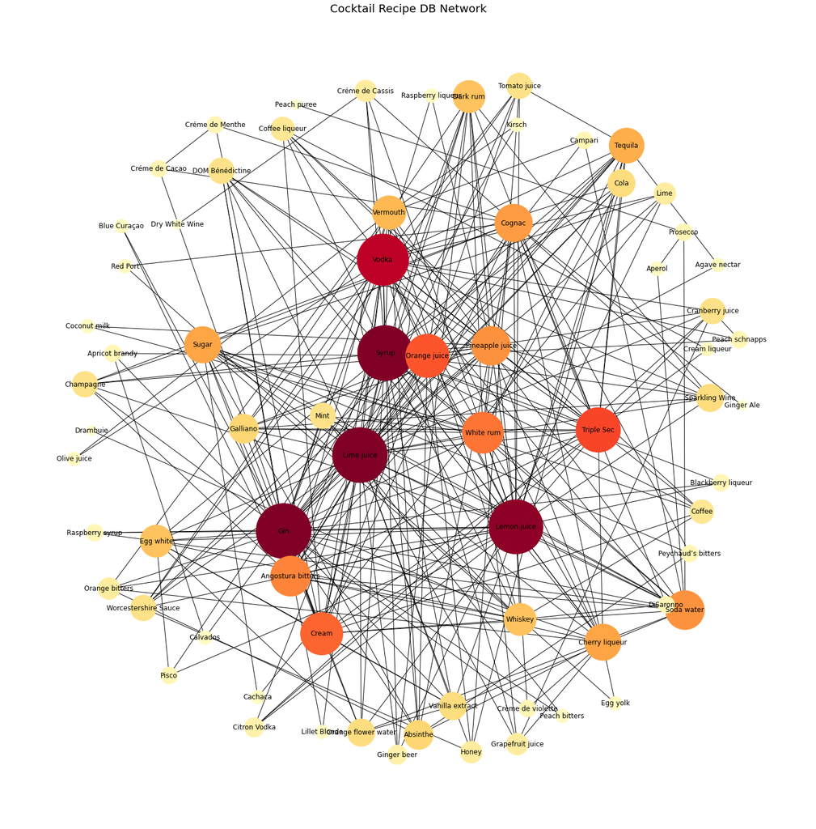

```python
pos=nx.spring_layout(G,k=2) # positions for all nodes
plt.figure(figsize=(20,20)) #Control figure size
nx.draw(G,pos,with_labels=True
        ,node_size = d * 300 # node size (degree에 비례한 노드 크기)
        ,node_color= d # data for label color (degree에 따른 컬러맵 사용)
        ,font_size= 12 # labelsize
        ,cmap=plt.cm.YlOrRd # color_map
       )
plt.title('Cocktail Recipe DB Network',size=20);
plt.savefig('Graph.png', format="PNG") # Save figure
```

크기가 커서 웹에서 쫌 깨져보이네요.... [이미지 크게 보기](https://trello.com/1/cards/62469d0f1dfc968cf7510f2b/attachments/6246a7b35d01db3790b230c3/download/image.png)

결론: 나머지 큰 재료들은 가지고 있으니까 진 한병 사면 더 많은 칵테일을 말아 먹을 수 있겠다!!!